# Supporting Material

## Can “easy” chemistry produce complex, diverse and novel molecules?

### Anna Tomberg and Jonas Boström*

Medicinal Chemistry, Research and Early Development, Cardiovascular, Renal and Metabolism, BioPharmaceuticals R&D, Astra-Zeneca, Gothenburg, Sweden.  
In this notebook, we use CHEMBL v.26 as a surrogate for the data sets in order to illustrate the way we processed and analyzed the data in the Astrazeneca ELN.

```python
#from __future__ import print_function

#####   TO PLOT   #####
import matplotlib.pyplot as plt
%matplotlib inline

from matplotlib_venn import venn2, venn2_circles, venn2_unweighted
from matplotlib_venn import venn3, venn3_circles
from matplotlib import pyplot as plt
import seaborn as sns

#####   RDKIT   #####
from rdkit import Chem
from rdkit.Chem import AllChem
from rdkit.Chem.Fingerprints import FingerprintMols
from rdkit.Chem import MACCSkeys
from rdkit import DataStructs
from rdkit.Chem import rdMolDescriptors
from rdkit.Chem import Draw
from rdkit.Chem.Draw.MolDrawing import MolDrawing, DrawingOptions
from rdkit.Chem.Draw import rdMolDraw2D
from rdkit.Chem.Draw import IPythonConsole #Needed to show molecules
IPythonConsole.ipython_useSVG = True
from IPython.display import display, SVG
from rdkit import SimDivFilters
from rdkit.SimDivFilters.rdSimDivPickers import MaxMinPicker
from rdkit.Chem import PandasTools


#####   OTHER   #####
import numpy as np
import pandas as pd
import random
import scipy as sp
from scipy import stats
import math, csv, optparse
```

## 1. Define paths and global constants

```python
my_file = "../CHEMBL26smallmolecule.smi"


SUBSET_SIZE = 10000 #how many to pick from each set formed by different reactions

SAMPLE_SIZE = 10  #how many to pick as most diverse to make tanimoto sim plots
```

## 2. Load & prep data : clean up, reformat

```python
my_chembl = pd.read_csv(my_file, sep=' ')
my_chembl.columns = ['SMILES']

print(len(my_chembl))
```

```
1940732
```

```python
my_chembl.head(5)
```

|  | SMILES |
| --- | --- |
| 0 | Cc1ccc(cc1)c2cc(no2)CN(Cc3ccccc3)C(CCCN=C(N)N)... |
| 1 | COCc1c(c(on1)O)Cc2ccc3ccccc3c2 |
| 2 | Cc1ccc2c(c1)c(=O)nc(n2c3ccccc3)C(C)C |
| 3 | Cc1cc(cc(c1C(=O)NCCN2CCN(CC2)c3ccccn3)C)N |
| 4 | c1cc(sc1CS)C(=N)N |

```python
# convert smiles to rdkit molecule object and remove examples with molecular weight over 1200

PandasTools.AddMoleculeColumnToFrame(my_chembl,'SMILES','Molecule',includeFingerprints=False)
my_chembl.dropna(subset = ["Molecule"], inplace=True)

my_chembl['MW'] = my_chembl.apply(lambda mol: Chem.rdMolDescriptors.CalcExactMolWt(mol['Molecule']), axis = 1)
my_chembl.drop(my_chembl[my_chembl.MW > 1200].index, inplace=True)
```

[output not shown]

SMILES

Molecule

MW

Index

0

Cc1ccc(cc1)c2cc(no2)CN(Cc3ccccc3)C(CCCN=C(N)N)...

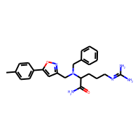

434.243024

1

COCc1c(c(on1)O)Cc2ccc3ccccc3c2

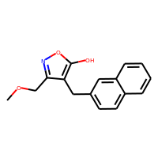

269.105193

2

Cc1ccc2c(c1)c(=O)nc(n2c3ccccc3)C(C)C

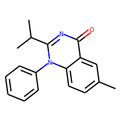

278.141913

3

Cc1cc(cc(c1C(=O)NCCN2CCN(CC2)c3ccccn3)C)N

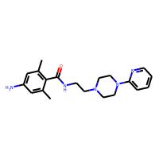

353.221560

4

c1cc(sc1CS)C(=N)N

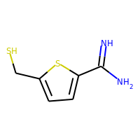

172.012890

```python
# add identifiers to molecules and save under smi and csv formats
my_chembl.index.names = ['Index']

my_chembl.head(5)
```

```python
my_chembl.to_csv('chembl_clean.csv', columns = ["SMILES", 'MW'], sep = ",")

my_data = pd.read_csv('chembl_clean.csv', sep=',')
my_data = my_data.rename(columns={'Index':'ID'})
display(my_data.head(5))

my_data.to_csv('chembl_clean.smi', columns = ["SMILES", "ID"], sep = " ", index=False)
```

|  | ID | SMILES | MW |
| --- | --- | --- | --- |
| 0 | 0 | Cc1ccc(cc1)c2cc(no2)CN(Cc3ccccc3)C(CCCN=C(N)N)... | 434.243024 |
| 1 | 1 | COCc1c(c(on1)O)Cc2ccc3ccccc3c2 | 269.105193 |
| 2 | 2 | Cc1ccc2c(c1)c(=O)nc(n2c3ccccc3)C(C)C | 278.141913 |
| 3 | 3 | Cc1cc(cc(c1C(=O)NCCN2CCN(CC2)c3ccccn3)C)N | 353.221560 |
| 4 | 4 | c1cc(sc1CS)C(=N)N | 172.012890 |

#### Hash entries and remove duplicates

```python
# the step can also be done with rdkit's Chem.rdMolHash
!bash /projects/cc/kntb373/chemical_databases/Run_oehash.sh chembl_clean.smi
```

[output not shown]

```python
add_header = ['ID', 'SMILES', 'hash']
chembl_clean = pd.read_csv('chembl_clean.oehash', sep = " ", names=add_header)
l1 = len(chembl_clean)
chembl_clean.drop_duplicates(subset = "hash", keep = "first", inplace = True)
l2 = len(chembl_clean)

print("Removed %i duplicate entries."%(l1-l2))
display(chembl_clean.head(5))

chembl_clean.drop(columns=['SMILES'], inplace = True);
```

[output not shown]

|  | ID | SMILES | hash |
| --- | --- | --- | --- |
| 0 | 0 | Cc1ccc(cc1)c2cc(no2)CN(Cc3ccccc3)C(CCCN=C(N)N)... | 18289272087588200501 |
| 1 | 1 | COCc1c(c(on1)O)Cc2ccc3ccccc3c2 | 2155150735798659182 |
| 2 | 2 | Cc1ccc2c(c1)c(=O)nc(n2c3ccccc3)C(C)C | 9957263274131958786 |
| 3 | 3 | Cc1cc(cc(c1C(=O)NCCN2CCN(CC2)c3ccccn3)C)N | 3549057925074720754 |
| 4 | 4 | c1cc(sc1CS)C(=N)N | 14376914910437432440 |

SMILES

Molecule

MW

ID

hash

0

Cc1ccc(cc1)c2cc(no2)CN(Cc3ccccc3)C(CCCN=C(N)N)...

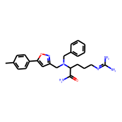

434.243024

0

18289272087588200501

1

COCc1c(c(on1)O)Cc2ccc3ccccc3c2

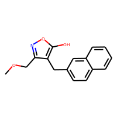

269.105193

1

2155150735798659182

2

Cc1ccc2c(c1)c(=O)nc(n2c3ccccc3)C(C)C

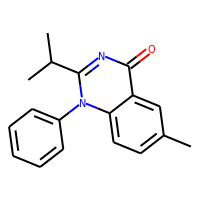

278.141913

2

9957263274131958786

3

Cc1cc(cc(c1C(=O)NCCN2CCN(CC2)c3ccccn3)C)N

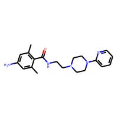

353.221560

3

3549057925074720754

4

c1cc(sc1CS)C(=N)N

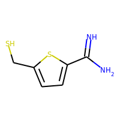

172.012890

4

14376914910437432440

```python
my_chembl = pd.merge(left = my_chembl, right = chembl_clean, left_on = 'Index', right_on = 'ID')
my_chembl.head(5)
```

#### Create two sets: amide formation & the rest, then select 10 000 from each set at random

- Find examples of molecules that have an ,amide bond - these will be part of the "amide formation" set.
- For the Astrazeneca ELN data, these sets were formed using the NextMove reaction classifications.

```python
amide_bond = Chem.MolFromSmarts("[NX3][CX3](=[OX1])[#6]")
amide_bond
```

```python
my_chembl['Has_amide'] = my_chembl.apply(lambda mol: (mol['Molecule']).HasSubstructMatch(amide_bond), axis = 1)

set_a = my_chembl[my_chembl['Has_amide']==True]
print("Size AMIDE set: ", len(set_a))
subset_1 = set_a.sample(n=SUBSET_SIZE, replace=False, weights=None, random_state=None, axis=None)

set_b = my_chembl[my_chembl['Has_amide']==False]
print("Size REST set: ", len(set_b))
subset_2 = set_b.sample(n=SUBSET_SIZE, replace=False, weights=None, random_state=None, axis=None)
```

```
Size AMIDE set:  891964
Size REST set:  1024086
```

```python
subset_1['ID'] = subset_1.apply(lambda row: ('c_'+str(row['ID'])), axis = 1)
subset_2['ID'] = subset_2.apply(lambda row: ('c_'+str(row['ID'])), axis = 1)
```

```python
subset_1.to_csv('subset_1.csv', columns = ["SMILES", "ID", 'MW', 'hash'], sep = ",")
subset_2.to_csv('subset_2.csv', columns = ["SMILES", "ID", 'MW', 'hash'], sep = ",")

# create a concatenated frame with both subsets (for clustering)
concat_subsets = pd.concat([subset_1,subset_2])
```

```python
concat_subsets.to_csv('subsets_concat.smi', columns = ["SMILES", "ID"], sep = " ", index = False)

subset_1.to_csv('subset_1.smi', columns = ["SMILES", "ID"], sep = " ", index = False)
subset_2.to_csv('subset_2.smi', columns = ["SMILES", "ID"], sep = " ", index = False)
```

## 3. Decide on the threshold for clustering

- extract 5010 random compounds for tanimoto comparison
- take out 10 random as reference molecules
- plot the tanimoto distribution wrt each ref molecule using the morgan and the maccs fingerprints

```python
tanimoto_set = my_data.sample(n=5010, replace=False, weights=None, random_state=42, axis=None)

# save into file
tanimoto_set.to_csv('tanimoto_set.smi', columns = ["SMILES"], sep = " ", index=False)
```

```python
def get_tanimoto_distr(ref_mols, sampled_mols_list, FP = None, radius = 3):
    # compute Tanimoto similarity to reference compound:

    ref_fps = []
    if FP == 'rdkit':
        ref_fps = [Chem.RDKFingerprint(ref, radius) for ref in ref_mols]
    elif FP == 'maccskeys':
        ref_fps = [MACCSkeys.GenMACCSKeys(ref) for ref in ref_mols]
    else:
        ref_fps = [AllChem.GetMorganFingerprint(ref, radius) for ref in ref_mols]

    all_similarities = []

    dissimilar_mols = []

    for sampled_mols in sampled_mols_list:
        sim_list = []
        for sample in sampled_mols:
            if FP == 'rdkit':
                mfp = Chem.RDKFingerprint(sample, radius)
            elif FP == 'maccskeys':
                mfp = MACCSkeys.GenMACCSKeys(sample)
            else:
                mfp = AllChem.GetMorganFingerprint(sample, radius)

            sim_samples = []
            for refp in ref_fps:
                ts = DataStructs.TanimotoSimilarity(mfp, refp)
                sim_samples.append(ts)
                if ts >= 0.99 :
                    break

            if max(sim_samples) < 0.2:
                dissimilar_mols.append(sample)

            sim_list.append(max(sim_samples))

        all_similarities.append(sim_list)

    return all_similarities, dissimilar_mols

def read_smiles(file):

    molecules = Chem.SmilesMolSupplier(file, nameColumn = -1)
    print(len(molecules))
    all_mols = []

    count = 0
    for mol in molecules:
        #print (count)
        if mol is not None:
            try:

                Chem.SanitizeMol(mol)
                #mol = Chem.RemoveHs(mol)
                AllChem.Compute2DCoords(mol)

                all_mols.append(mol)

            except:
                print("Error: unreasonable molecule.")
        count = count+1

    print(">>> Read in", len(all_mols), "molecules out of", len(molecules), "from", file)

    return all_mols
```

```python
sample_mols = read_smiles('tanimoto_set.smi')
while sample_mols.count(None): sample_mols.remove(None)
len(sample_mols)
```

```
5010
>>> Read in 5010 molecules out of 5010 from tanimoto_set.smi
```

```
5010
```

### 3.1. Pick samples using random

```python
ref_samples = random.sample(sample_mols, SAMPLE_SIZE)
new_samples = [x for x in sample_mols if x not in ref_samples]


while len(new_samples) > 5000:
    # Remove random element from list
    new_samples.pop(random.randrange(len(new_samples)))

print("Ref len:", len(ref_samples))
print("Samples len:", len(new_samples))
```

```
Ref len: 10
Samples len: 5000
```

### 3.2. Check examples

```python
# Draw the molecule pairs.  Change molsPerRow and subImgSize to make images bigger (MAX 50 mols at a time)
img = Draw.MolsToGridImage(ref_samples,molsPerRow=2, subImgSize=(300, 200) ) #,useSVG=False)
# show here:
img
```

[figure not shown]

### 3.3. Compute the morgan fps and the maccs fps in RDkit

```python
all_simi_morgan = list()
all_simi_maccs = list()

for ref in ref_samples:
    #display(ref)
    similarities, dissimilar_mols = get_tanimoto_distr([ref], [ref_samples,new_samples])
    all_simi_morgan.append(similarities[1])

    similarities, dissimilar_mols = get_tanimoto_distr([ref], [ref_samples,new_samples], FP = 'maccskeys')
    all_simi_maccs.append(similarities[1])
```

### 3.4. Plot everything

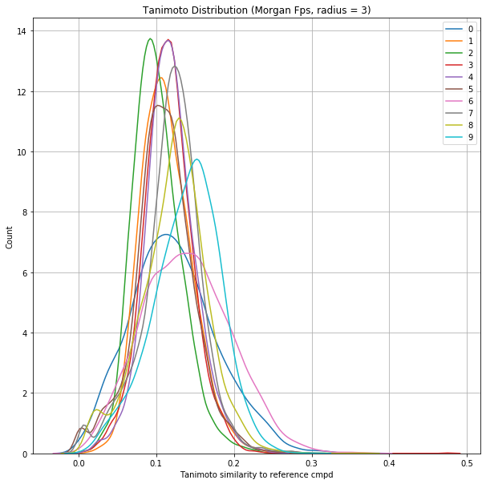

```python
fig = plt.figure(figsize=(10,10))
for simi in all_simi_morgan:
    #n, bins, patches = plt.hist(simi,bins=50, color='b',alpha=0.5, label='sample_mols')
    ax = sns.distplot(simi, hist=False, label = all_simi_morgan.index(simi), \
                      kde_kws={"shade": False}) #,fit=stats.norm)


#n, bins, patches = plt.hist(similarities[0],bins=50, color='g',alpha=0.5, label='reference')

plt.xlabel('Tanimoto similarity to reference cmpd')
plt.ylabel('Count')
plt.title('Tanimoto Distribution (Morgan Fps, radius = 3)')
#plt.title('Tanimoto Distribution (MACCS Fps)')
plt.grid(True)
plt.legend()
plt.show();
```

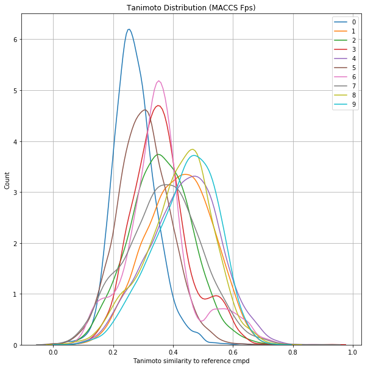

```python
fig = plt.figure(figsize=(10,10))
for simi in all_simi_maccs:
    #n, bins, patches = plt.hist(simi,bins=50, color='b',alpha=0.5, label='sample_mols')
    ax = sns.distplot(simi, hist=False, label = all_simi_maccs.index(simi), \
                      kde_kws={"shade": False}) #,fit=stats.norm)


#n, bins, patches = plt.hist(similarities[0],bins=50, color='g',alpha=0.5, label='reference')

plt.xlabel('Tanimoto similarity to reference cmpd')
plt.ylabel('Count')
#plt.title('Tanimoto Distribution (Morgan Fps, radius = 3)')
plt.title('Tanimoto Distribution (MACCS Fps)')
plt.grid(True)
plt.legend()
plt.show();
```

## 4. Generate files with molecular fingerprints that can be used by chemfp

```python
# command line of create_fps_files.sh:

! bash ../create_fps_files.sh

# will print error message trying to parse the headers: doesn't matter.
```

```
[09:18:05] SMILES Parse Error: syntax error for input: 'SMILES'
[09:18:43] SMILES Parse Error: syntax error for input: 'SMILES'
[09:19:22] SMILES Parse Error: syntax error for input: 'SMILES'
[09:19:28] SMILES Parse Error: syntax error for input: 'SMILES'
[09:19:33] SMILES Parse Error: syntax error for input: 'SMILES'
[09:20:50] SMILES Parse Error: syntax error for input: 'SMILES'
```

## 5. Taylor-Butina clustering

After the creation of the fps files, run the taylor_butina_clustering.py for the next step.  
https://baoilleach.blogspot.com/2019/11/comparing-chemical-spaces.html?_sm_au_=iVVRsNWQRLPN89vMpGsWvKttvN1NG

```python
# to run clustering on both types of fingerprints at threshold = [0.35] for morgan and [0.75] for maccs
! bash ../run_clustering.sh
```

```python
# created these files:

cluster_files = ["maccs_75_clusters.txt", "morgan_035_clusters.txt"];
```

```python
# From blog:

def read_clustering_output(filename):
    # clusters will be a list of lists
    clusters = list()

    with open(filename, 'r') as fo:
        for line in fo.readlines():
            if line.startswith('>>singletons:'):
                # each singleton is its own cluster
                c = (line.split())[1:]
                for x in c:
                    clusters.append([x])
                    #print([x])

            elif line.startswith('>>cluster:'):
                c = (line.split())[1:]
                #print(c)
                clusters.append(c)

    return clusters

def invert_dict(d):

    # inverts from clusters-> list of ids to each id-> its cluster
    inverse = dict()
    for key in d:
        # Go through the list that is saved in the dict:
        for item in d[key]:
            # Check if in the inverted dict the key exists
            if item not in inverse:
                # If not create a new list
                inverse[item] = key
            #else:
                #inverse[item].append(key)
    return inverse

def clusters_to_df(list_of_clusters, name_tag):
    my_df = ''

    # convert list of clusters into a dictionary
    my_dict = { i : list_of_clusters[i] for i in range(0, len(list_of_clusters) ) }
    my_dict = invert_dict(my_dict)

    # convert to df of correct format
    my_df = pd.DataFrame.from_dict(my_dict, orient='index', columns = [name_tag])
    my_df.reset_index(inplace = True)
    #my_df = my_df.rename(columns={"index": "ELN_ID"})


    return my_df

def check_subset(list_of_ids, set1, set2):
    is_in = list()

    for i in list_of_ids:
        #print(i)

        if i in set1:
            is_in.append(1)
        elif i in set2:
            is_in.append(2)
        else:
            print('cant find in sets:', i)
            return ''

    my_set = set(is_in)
    if 1 in my_set and 2 in my_set:
        return 'both'
    elif 1 in my_set:
        return 'set1'
    elif 2 in my_set:
        return 'set2'
    else:
        print('cant assign')
        return ''
```

## 6. Process clustering results & plot

```python
#subset_1 = pd.read_csv('subset_1.csv', sep = " ")
#subset_2 = pd.read_csv('subset_2.csv', sep = " ")
```

SMILES

Molecule

MW

ID

hash

Has_amide

929691

c1cc(c(cc1C(F)(F)F)NC(=O)CN2C(=O)C3(CCCC3)NC2=...

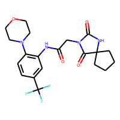

440.167140

c_943046

12013344949554913448

True

1410118

Cc1cc(ccc1c2cccc3c2[nH]c(c3CCCOc4cccc5c4cccc5)...

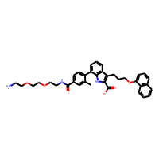

609.283886

c_1429009

16672496934114522145

True

205655

CCC(CC)NC(=O)c1cnn(c1NS(=O)(=O)c2ccc(cc2)C)c3c...

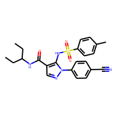

451.167811

c_209409

1832261018348306474

True

799383

Cc1ccc(cc1)S(=O)(=O)N2CCN(CC2)C(=O)Cc3ccccc3

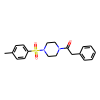

358.135114

c_811222

9414749699996955415

True

1485294

CCCOc1cccc(c1)c2cc(c3ccccc3n2)C(=O)N/N=C/c4ccccn4

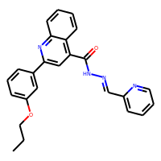

410.174276

c_1505034

11575490658484637727

True

...

...

...

...

...

...

...

340029

CC1(CCC(=CC1)c2cc(ccc2NC(=O)c3[nH]c(cn3)C#N)[C...

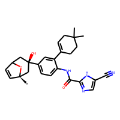

444.216141

c_345833

13376555746444022343

True

775534

c1ccnc(c1)c2ccc(nn2)N3CCN(CC3)C(=O)C4CCCC4

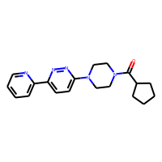

337.190260

c_787097

1315566120771124040

True

1131256

c1cc(ccc1CNCc2cc(cc(c2)NC(=O)CN3CCCCC3)Nc4ccnc...

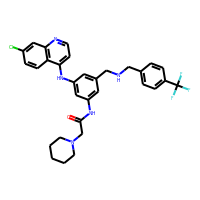

581.216923

c_1146971

15686633634825959621

True

492308

Cc1cc(ccc1F)CN2[C@H]3[C@H]4CC[C@H](C4)[C@H]3C(...

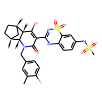

574.135605

c_500239

10179679519004526597

True

749159

CC1(CCN1C(=O)c2cccc(c2)OC(F)(F)F)C(=O)O

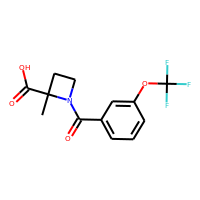

303.071843

c_760385

13793668188055716815

True

10000 rows × 6 columns

```python
subset_1
```

```python
list_of_ids_sub1 = list(subset_1['ID'])
list_of_ids_sub2 = list(subset_2['ID'])
```

```
Working on: maccs_75_clusters.txt
Clusters found 5813
Number of molecules in clusters with only Set1: 4095
Number of molecules in clusters with only Set2: 6462
Number of molecules in clusters with both: 7557
```

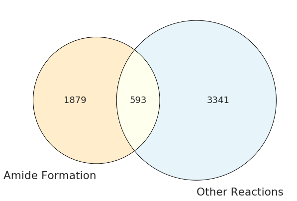

```
Working on: morgan_035_clusters.txt
Clusters found 6559
Number of molecules in clusters with only Set1: 4710
Number of molecules in clusters with only Set2: 5783
Number of molecules in clusters with both: 7419
```

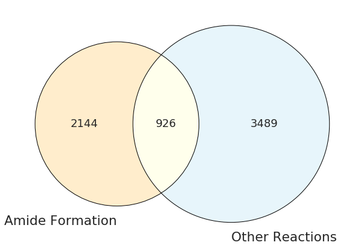

```python
for f in cluster_files:
    # name the baby:
    print("Working on:", f)

    # read output txt file
    my_clusters = read_clustering_output(f)
    print("Clusters found", len(my_clusters))

    # create and manipulate dictionary/dataframe to get clusters into a manageable data structure
    my_dict = { i : my_clusters[i] for i in range(0, len(my_clusters) ) }
    my_df = pd.DataFrame.from_dict([my_dict])
    my_df = my_df.transpose()
    my_df.reset_index(inplace = True)
    my_df = my_df.rename(columns={"index": "Cluster#", 0:'IDs'})
    #print(my_df.head(5))

    # compute size of clusters
    my_df['Cluster_Size'] = my_df['IDs'].apply(lambda x: len(x))

    # assign cluster to subgroup for venn diagram
    my_df['Is_in'] = my_df['IDs'].apply(lambda x: check_subset(x, list_of_ids_sub1, list_of_ids_sub2))

    # print numbers of molecules in clusters of only set1, only set2, and mix:
    print("Number of molecules in clusters with only Set1:", my_df[my_df["Is_in"]=="set1"].sum()["Cluster_Size"])
    print("Number of molecules in clusters with only Set2:", my_df[my_df["Is_in"]=="set2"].sum()["Cluster_Size"])
    print("Number of molecules in clusters with both:", my_df[my_df["Is_in"]=="both"].sum()["Cluster_Size"])

    groups_count = my_df.groupby(['Is_in']).count()
    #print(groups_count)

    # create a venn diagram:
    plt.figure(figsize=(10,10))
    sns.set_style("white")
    sns.set_context("talk")

    venn2(subsets = (groups_count.loc["set1"]["Cluster#"], groups_count.loc["set2"]["Cluster#"], \
                     groups_count.loc["both"]["Cluster#"]),\
          set_labels = ("Amide Formation", "Other Reactions"), set_colors=("orange","skyblue"), alpha = 0.2);

    venn2_circles(subsets = (groups_count.loc["set1"]["Cluster#"], groups_count.loc["set2"]["Cluster#"], \
                     groups_count.loc["both"]["Cluster#"]), linewidth=1, color='k');
    #plt.title()
    plt.show();
    #plt.savefig(f.replace('_clusters.txt','_Venn.png'), dpi=1200);
```

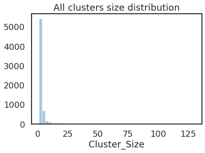

```python
sns.distplot(my_df["Cluster_Size"], hist=True, kde =False);
plt.title('All clusters size distribution')
plt.show();
```

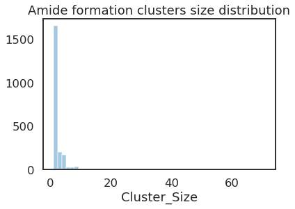

```python
my_df[my_df["Is_in"]=="set1"]["Cluster_Size"]
sns.distplot(my_df[my_df["Is_in"]=="set1"]["Cluster_Size"], hist=True, kde =False);
plt.title('Amide formation clusters size distribution')
plt.show();
```

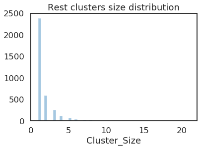

```python
sns.distplot(my_df[my_df["Is_in"]=="set2"]["Cluster_Size"], hist=True, kde =False);
plt.title('Rest clusters size distribution')
plt.show();
```

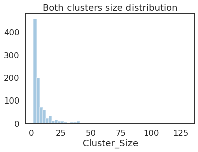

```python
sns.distplot(my_df[my_df["Is_in"]=="both"]["Cluster_Size"], hist=True, kde =False);
plt.title('Both clusters size distribution')
plt.show();
```

## 7. Calculate "molecular complexities"

```python
! bash ../run_complexityMACCS.sh

# produces 2 files: complexreport_subset1.csv and complexreport_subset2.csv
# both have same format: MolName,MACCS-Complexity,Bertz-Complexity,MW
```

## 8. Calculate Cohen's d

```python
# make dataframes for each subset and prepare input for Cohen's d calculation

sub1_df = pd.read_csv("complexreport_subset1.csv")
display(sub1_df.head(5))

sub2_df = pd.read_csv("complexreport_subset2.csv")
display(sub2_df.head(5))
```

|  | MolName | MACCS-Complexity | Bertz-Complexity | MW | fSP3 |
| --- | --- | --- | --- | --- | --- |
| 0 | c_c_65878 | 0.28 | 0.61 | 515.00 | 0.08 |
| 1 | c_c_1731027 | 0.24 | 0.39 | 316.42 | 0.27 |
| 2 | c_c_492420 | 0.50 | 1.42 | 725.85 | 0.43 |
| 3 | c_c_122932 | 0.33 | 0.80 | 546.70 | 0.45 |
| 4 | c_c_32946 | 0.30 | 0.41 | 272.34 | 0.30 |

|  | MolName | MACCS-Complexity | Bertz-Complexity | MW | fSP3 |
| --- | --- | --- | --- | --- | --- |
| 0 | c_16442 | 0.30 | 0.75 | 442.63 | 0.56 |
| 1 | c_1852127 | 0.15 | 0.37 | 350.41 | 0.40 |
| 2 | c_1253890 | 0.11 | 0.15 | 187.71 | 0.83 |
| 3 | c_945471 | 0.23 | 0.29 | 273.76 | 0.26 |
| 4 | c_954486 | 0.27 | 0.64 | 396.48 | 0.17 |

Calculate Cohen's d (https://rpsychologist.com/d3/cohend) and visualize the results, also in jupyter  
There's a script to help here: /projects/cc/kemijbo/tools/python/cohensEffectSize.py  
Created on Wed Oct 28 11:39:27 2015  
calculates the effect size using Cohens d, an error for d and  
an odds of an individual observation from one set being greater  
than an observation from the other set (odds ratio).  
@author: Paul Hawkins  
Effect size estmation using Cohen's d. Larger d = more substantial effect/difference between two methods.  
THIS IS NOT IN ANY WAY RELATED TO STATISTICAL SIGNIFICANCE.  
d <= 0.2 - trivial effect (there is no difference worth worrying about)  
0.2 <= d < 0.5 - small effect.  
0.5 <= d <= 0.8 - medium effect.  
d > 0.8 - large effect.  
Bertz, S. H. The first general index of molecular complexity. J. Am. Chem. Soc. 1981, 103, 3599−3601.

```python
def readFile(matchedPairFile):
    return reader

def CohensEffectSize(lis1,lis2):
    n1=len(lis1)
    n2=len(lis2)
    mean1=np.mean(lis1)
    mean2=np.mean(lis2)
    stddev1=np.std(lis1)
    stddev2=np.std(lis2)
    #    s1=math.sqrt((stddev1**2 + stddev2**2)/2)
    s2=math.sqrt((n1-1)*stddev1**2 + (n2-1)*stddev2**2)
    #    d1=round(math.fabs(mean1-mean2)/s1,3)
    d2=round(math.fabs(mean1-mean2)*math.sqrt(n1+n2-2)/s2,3)
    return d2

# Analytical estimation of the error in Cohen's d. From Ant's 2014 paper in JCAMD.
# In what range is the actual d, the population parameter, likley to lie?
def CohensError(d,n):
    err_d2 = (1 + math.sqrt(2)*d**2)/n # from Ant's 2014 JCAMD paper on confidence intervals
    err_d = math.sqrt(err_d2)
    return err_d # this is the SE of the error. +/-1.96*err_d gives the 95% CI for actual d.

# Odds of one method outperforming another in the next single comparison
def EffectSizeOddsRatio(eff_size): # see Stats in Medicine, 19, 3127 (2000) S. Chinn
    odds = math.exp(eff_size*math.pi/math.sqrt(3))
    ratio = 100/odds
    y = round(100/(odds+1),1)
    x = 100 - y

    return odds,x,y
```

```python
print('MACCS-Complexity')
val1List = list(sub1_df['MACCS-Complexity'])
val2List = list(sub2_df['MACCS-Complexity'])
diffList = list(sub1_df['MACCS-Complexity']-sub2_df['MACCS-Complexity'])
n = len(val1List)        # number of entries

meanDiff = np.mean(diffList)
d2 = CohensEffectSize(val1List,val2List)
d = math.sqrt(d2)
err_d = CohensError(d,n)

print("mean diff is: %.2f" % meanDiff)
print("Cohen's d is: %.2f" % d)
print("d2 is: %.2f" % d2)
print("err_d is: %.2f" % err_d)


print("mean Amide Formation is: %.2f" % np.mean((list(sub1_df['MACCS-Complexity']))))
print("mean Other Reactions is: %.2f" % np.mean((list(sub2_df['MACCS-Complexity']))))
```

```
MACCS-Complexity
mean diff is: 0.05
Cohen's d is: 0.87
d2 is: 0.75
err_d is: 0.01
mean Amide Formation is: 0.32
mean Other Reactions is: 0.27
```

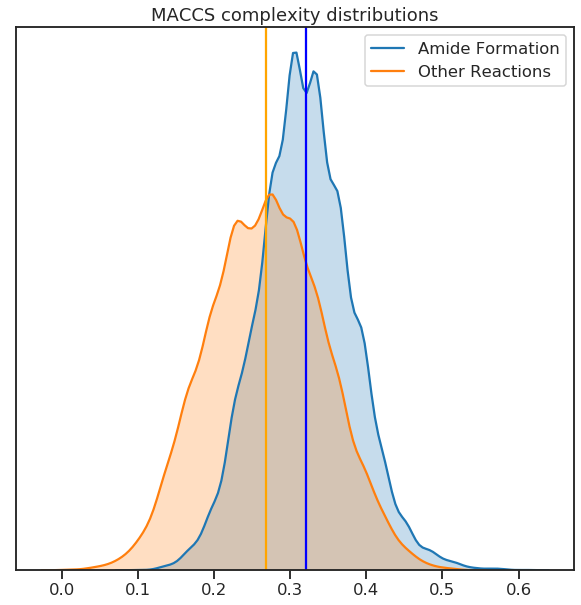

```python
# plot nice plots

plt.figure(figsize=(10,10))
sns.set_style("ticks")
sns.set_context("talk")

ax = sns.distplot(val1List, hist=False, label = 'Amide Formation', kde_kws={"shade": True}) #,fit=stats.norm)
ax = sns.distplot(val2List, hist=False, label = 'Other Reactions', kde_kws={"shade": True}) #, fit=stats.norm)

kde = stats.gaussian_kde(val1List) # Compute the Gaussian KDE
idx = np.argmax(kde.pdf(val1List)) # Get the index of the maximum
#plt.axvline(val1List[idx], color='blue') # Plot a vertical line at corresponding val1List

plt.axvline(np.mean(list(sub1_df['MACCS-Complexity'])), color='blue')

kde = stats.gaussian_kde(val2List) # Compute the Gaussian KDE
idx = np.argmax(kde.pdf(val2List)) # Get the index of the maximum
#plt.axvline(val2List[idx], color='orange')  # Plot a vertical line at corresponding val1List
plt.axvline(np.mean(list(sub2_df['MACCS-Complexity'])), color='orange')


plt.title('MACCS complexity distributions')
plt.yticks([])


plt.show()
plt.savefig('maccs_complexity.svg', dpi=1200);
```

```python
print('Bertz-Complexity')
val1List = list(sub1_df['Bertz-Complexity'])
val2List = list(sub2_df['Bertz-Complexity'])
diffList = list(sub1_df['Bertz-Complexity']-sub2_df['Bertz-Complexity'])
n = len(val1List)        # number of etries

meanDiff = np.mean(diffList)
d2 = CohensEffectSize(val1List,val2List)
d = math.sqrt(d2)
err_d = CohensError(d,n)

print("mean diff is: %.2f" % meanDiff)
print("Cohen's d is: %.2f" % d)
print("d2 is: %.2f" % d2)
print("err_d is: %.2f" % err_d)

print("mean Amide Formation set is: %.2f" % np.mean((list(sub1_df['Bertz-Complexity']))))
print("mean Other Reactions is: %.2f" % np.mean((list(sub2_df['Bertz-Complexity']))))
```

```
Bertz-Complexity
mean diff is: 0.08
Cohen's d is: 0.51
d2 is: 0.26
err_d is: 0.01
mean Amide Formation set is: 0.67
mean Other Reactions is: 0.59
```

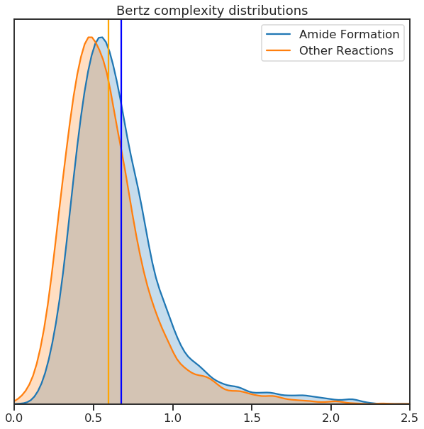

```python
# plot nice plots
plt.figure(figsize=(10,10))
sns.set_style("ticks")
sns.set_context("talk")

ax = sns.distplot(val1List, hist=False, label = 'Amide Formation', kde_kws={"shade": True}) #,fit=stats.norm)
ax = sns.distplot(val2List, hist=False, label = 'Other Reactions', kde_kws={"shade": True}) #, fit=stats.norm)

kde = stats.gaussian_kde(val1List) # Compute the Gaussian KDE
idx = np.argmax(kde.pdf(val1List)) # Get the index of the maximum
#plt.axvline(val1List[idx], color='blue') # Plot a vertical line at corresponding val1List
plt.axvline(np.mean(list(sub1_df['Bertz-Complexity'])), color='blue')

kde = stats.gaussian_kde(val2List) # Compute the Gaussian KDE
idx = np.argmax(kde.pdf(val2List)) # Get the index of the maximum
#plt.axvline(val2List[idx], color='orange')  # Plot a vertical line at corresponding val1List
plt.axvline(np.mean(list(sub2_df['Bertz-Complexity'])), color='orange')

plt.title('Bertz complexity distributions')
plt.yticks([])
plt.xlim(0, 2.5)


plt.show()
plt.savefig('bertz_complexity.png', dpi=1200);
```

## 9. CHEMBL data comparison

For novel chemistry/compounds: check ”exact match” for the two sets against ChEMBL

- downloaded Chembl26: https://www.ebi.ac.uk/chembl/g/#browse/compounds
- Here, we will skip this part, since the surrogate dataset is already from CHEMBL

Procedure:

- hash chembl compounds
- hash subset1 & 2, then merge based on hashes
- count how many were found

## 10. Compare EGID from IBIS dataset

- Define activite as pIC50 > 5 (10µM)
- Are there targets (EGID) that are unique to one set or the other?
- EGID is Entrez Gene ID

Procedure:

- hash AZ IBIS dataset, with target information
- merge with subset1 and 2, based on hashes
- extract target info
- plot venn diagrams based on common and unique EGIDs